# Proyecto de Café Premium

```
Somos el equipo de datos de una marca de café de especialidad que quiere romper el mercado. No aspiramos a ser “otro café más”: nuestro objetivo es convertirnos en la referencia absoluta para personas exigentes que ya no soportan el café plano y repetitivo de las cadenas masivas.
```

Nuestra misión es clara: convertirnos en el distribuidor número uno para amantes del café premium. No se trata solo de vender más, sino de vender mejor: el origen adecuado, el tueste perfecto y al cliente correcto. Nuestra propuesta de valor se basa en tres pilares fundamentales:

- seleccionar los mejores orígenes,
- aplicar el tostado más adecuado para cada café,
- ofrecer una calidad alta y consistente. El reto es que los datos nos llegan en bruto y con bastante caos. Si construimos un modelo deficiente, tomaremos decisiones equivocadas y perderemos ventaja frente a la competencia. Por eso nuestro trabajo consiste en transformar esos datos, darles sentido y convertirlos en una herramienta estratégica que nos permita diferenciarnos de verdad.

## 🚀 Objetivo 1: pasar de una tabla desordenada (`ventas_cafe_raw`) a un modelo relacional en 3FN sin perder informacion.

```python
import sqlite3
import pandas as pd

# Ajusta la ruta si tu ventas-cafe-raw.db está en otra carpeta
con = sqlite3.connect("../01_datos_iniciales/archivos_db/tostador-cafe-raw2.db")

# ¿Qué tablas hay disponibles?
pd.read_sql("SELECT name FROM sqlite_master WHERE type='table'", con)
```

|  | name |
| --- | --- |
| 0 | ventas_cafe_raw |

### 🔎 1. Visualizamos la base de datos inicial y desordenada.

Antes de hacer ningún cambio vamos a realizar unas métricas iniciales para posteriormente verificar que no cometemos errores al realizar el proceso de normalizacion:

En primer lugar hacemos una consulta para ver el número de filas que tiene la tabla de datos inicial:

```python
pd.read_sql("SELECT COUNT(*) AS filas_raw FROM 'ventas_cafe_raw'", con)
```

|  | filas_raw |
| --- | --- |
| 0 | 119 |

Hacemos una segunda consulta en la que unicamente queremos ver cúantas operaciones de venta hay:

```python
pd.read_sql("""
SELECT COUNT(DISTINCT id_venta) AS ventas_unicas_raw FROM ventas_cafe_raw;
""",con)
```

|  | ventas_unicas_raw |
| --- | --- |
| 0 | 98 |

Y una tercera consulta para ver cual es el importe total de ventas:

```python
pd.read_sql("""
SELECT ROUND(SUM(total_venta), 2) AS facturacion_raw FROM ventas_cafe_raw;
""",con)
```

|  | facturacion_raw |
| --- | --- |
| 0 | 3371.48 |

```python
from IPython.display import HTML

HTML("""
<style>

/* --- Efecto hover premium con animación --- */
.premium-table td {
    transition: background-color 0.25s ease, color 0.25s ease;
}

.premium-table td:hover {
    background-color: #C8923A !important;
    color: #1A0800 !important;
    cursor: pointer;
}

</style>
""")
```

```python
# Antes de empezar, importamos las librerias que vamos a utilizar:

import sqlite3
import pandas as pd
import matplotlib.pyplot as plt
import seaborn as sns

# === Tema de estilo Café Premium para DataFrames ===

premium_styles = [
    {"selector": "th",
     "props": "background-color: #C8923A; color: #1A0800; font-weight: bold; padding: 8px;"},

    {"selector": "td",
     "props": "background-color: #2A1205; color: #F2E0C8; padding: 6px;"},

    {"selector": "table",
     "props": "border: 1px solid #C8923A; border-collapse: collapse;"}
]

premium_props = {
    "border": "1px solid #C8923A",
    "padding": "6px"
}

# === Zebra premium (filas alternas) ===
def premium_zebra(row):
    if row.name % 2 == 0:
        return ['background-color: #2A1205; color:#F2E0C8'] * len(row)
    else:
        return ['background-color: #1E0D02; color:#F2E0C8'] * len(row)

# === Función para estilizar cualquier DataFrame ===
def estilizar(df, zebra=False):
    styled = (
        df.style
        .set_table_styles(premium_styles)
        .set_properties(**premium_props)
        .set_table_attributes('class="premium-table"')  # Clase para el hover
    )
    if zebra:
        styled = styled.apply(premium_zebra, axis=1)
    return styled

DB_PATH = "../01_datos_iniciales/archivos_db/tostador-cafe-raw.db"
conn = sqlite3.connect(DB_PATH)
```

## **El ejercicio plantea una serie de cuestiones y las divide en varios apartados que resolveremos a continuación:**

## Parte A – Diagnóstico

### 1. Seis problemas de diseño o calidad de dato

- **Redundancia de datos:** `email_cliente` y `nombre_cliente` se repiten en cada fila de venta.
- **Mezcla de entidades:** la tabla contiene datos del cliente, del producto, de la zona y de la venta en un solo lugar.
- **Formato inconsistente:** la columna `formato_paquete` mezcla unidades (kg, gr) y cantidades.
- **Datos subjetivos:** las columnas `valoración` y `comentario_valoración` dependen de criterios personales.
- **Inconsistencias en el precio del café:** no queda claro si son errores o promociones.
- **Valoraciones duplicadas:** la valoración depende del canal (online/tienda), pero lo que se valora es el café.

### 2. Una anomalía de inserción

No se puede dar de alta un café, zona o cliente sin registrar antes una venta, ya que todo depende de `id_venta`.

### 3. Una anomalía de actualización

Actualizar un email obliga a modificarlo en todas las filas donde aparece, con riesgo de inconsistencias.

### 4. Una anomalía de borrado

Si se borra la única venta de Pola de Lena, desaparece también la zona de la base de datos.

## Parte B – Normalización

### 1. Propuesta de tablas finales (PK y FK claras)

[figure not shown]

### 2. Paso por 1FN, 2FN y 3FN

Se aplicó el proceso de normalización para eliminar redundancias, dependencias parciales y dependencias transitivas. El resultado es un modelo relacional más limpio, eficiente y preparado para análisis posteriores.

[figure not shown]

### Ejemplo de creación de tablas

```sql
CREATE TABLE "cafe" (
  "id_cafe" INTEGER NOT NULL,
  "nombre_cafe" TEXT NOT NULL,
  "origen_cafe" TEXT NOT NULL,
  "proceso_cafe" TEXT NOT NULL,
  "nivel_tueste" TEXT NOT NULL,
  PRIMARY KEY("id_cafe")
);
```

### Ejemplo de inserción de datos

```sql
INSERT INTO cafe (id_cafe, nombre_cafe, origen_cafe, proceso_cafe, nivel_tueste)
SELECT DISTINCT id_cafe, nombre_cafe, origen_cafe, proceso_cafe, nivel_tueste
FROM ventas_cafe_raw;
```

### Consulta de la tabla resultante

```sql
conn = sqlite3.connect("../01_datos_iniciales/archivos_db/tostador-cafe-raw.db")
pd.read_sql("SELECT * FROM cafe;", conn)
```

### Resultado de la tabla `cafe`

| id_cafe | nombre_cafe | origen_cafe | proceso_cafe | nivel_tueste |
| --- | --- | --- | --- | --- |
| 1 | Colombia Huila | Colombia | Lavado | Medio |
| 2 | Etiopia Yirgacheffe | Etiopia | Lavado | Claro |
| 3 | Brasil Cerrado | Brasil | Natural | Medio |
| 4 | Guatemala Antigua | Guatemala | Honey | Medio-Oscuro |
| 5 | Peru Cajamarca | Peru | Lavado | Claro |
| 6 | Kenia Nyeri | Kenia | Lavado | Claro |

### Protocolo anti-pérdida de datos

Una vez pobladas nuestras tablas, comprobamos si las métricas iniciales coinciden con las de la base de datos normalizada.

#### 1ª métrica: Número de filas

El número de filas original era **119**.

```python
filas = pd.read_sql("SELECT COUNT(*) AS filas_normalizado FROM detalle_venta;", conn)

estilizar(filas)
```

|  | filas_normalizado |
| --- | --- |
| 0 | 119 |

#### 2ª métrica: Número de ventas unicas

Antes teniamos **98** ventas únicas.

```python
ventas_unicas = pd.read_sql("SELECT COUNT(DISTINCT id_venta) AS ventas_unicas_normalizadas FROM venta;", conn)

estilizar(ventas_unicas)
```

|  | ventas_unicas_normalizadas |
| --- | --- |
| 0 | 98 |

#### 3ª métrica: Facturación total

Nuestro importe final de ventas era de **3371.48**.

```python
facturacion = pd.read_sql("SELECT ROUND(SUM(total_venta), 2) AS facturacion_normalizada FROM detalle_venta;", conn)

estilizar(facturacion)
```

|  | facturacion_normalizada |
| --- | --- |
| 0 | 3371.480000 |

Hemos conseguido pasar de una tabla con datos sin organizar a una tabla normalizada en la que las métricas coinciden.  
**¡Objetivo 1 CONSEGUIDO!**

## 🚀 Objetivo 2: Responder a las preguntas SQL de negocios

### Consulta 1: Los 5 cafes con mayor facturacion

```python
cafes = pd.read_sql("""SELECT c.id_cafe, c.nombre_cafe, SUM(dv.total_venta) AS Total_facturacion
FROM detalle_venta AS dv
INNER JOIN cafe as c
	ON c.id_cafe = dv.id_cafe
GROUP BY nombre_cafe
ORDER BY SUM(dv.total_venta) DESC
LIMIT 5;""", conn)


estilizar(cafes, zebra=True)
```

|  | id_cafe | nombre_cafe | Total_facturacion |
| --- | --- | --- | --- |
| 0 | 2 | Etiopia Yirgacheffe | 896.370000 |
| 1 | 1 | Colombia Huila | 766.960000 |
| 2 | 4 | Guatemala Antigua | 508.800000 |
| 3 | 6 | Kenia Nyeri | 476.830000 |
| 4 | 3 | Brasil Cerrado | 395.940000 |

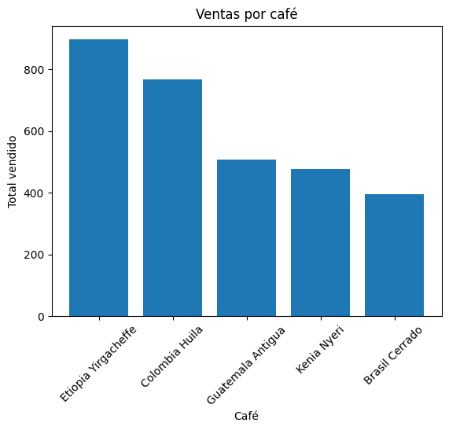

```python
plt.bar(cafes['nombre_cafe'], cafes['Total_facturacion'])
plt.xticks(rotation=45)
plt.title("Ventas por café")
plt.xlabel("Café")
plt.ylabel("Total vendido")
plt.show()
```

### Consulta 2: Zonas con mayor volumen de ventas

Opcion 1. Zonas con mayor volumen de ventas (por facturación)

```python
zona = pd.read_sql("""SELECT z.id_zona, z.nombre_zona AS Ciudad, SUM(dv.total_venta) AS Ventas
FROM zona as z
INNER JOIN cliente as cl
	ON z.id_zona = cl.id_zona
INNER JOIN venta as v
	ON cl.id_cliente = v.id_cliente
INNER JOIN detalle_venta as dv
	ON v.id_venta = dv.id_venta
GROUP BY nombre_zona
ORDER BY SUM(dv.total_venta) DESC;""", conn)

estilizar(zona, zebra=True)
```

|  | id_zona | Ciudad | Ventas |
| --- | --- | --- | --- |
| 0 | 1 | Oviedo | 764.000000 |
| 1 | 5 | Villaviciosa | 722.440000 |
| 2 | 2 | Gijon | 625.350000 |
| 3 | 3 | Aviles | 515.840000 |
| 4 | 4 | Nava | 513.500000 |
| 5 | 6 | Pola de Lena | 230.350000 |

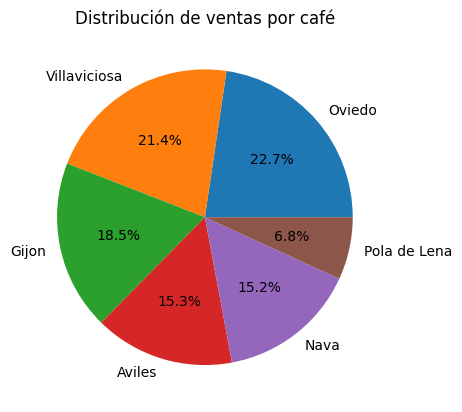

```python
plt.pie(zona['Ventas'], labels=zona['Ciudad'], autopct='%1.1f%%')
plt.title("Distribución de ventas por café")
plt.show()
```

Opcion 2: Zonas con mayor volumen de ventas (por unidades vendidas)

```python
zona2 = pd.read_sql("""SELECT z.id_zona, z.nombre_zona, SUM(dv.cantidad) AS unidades
FROM zona as z
INNER JOIN detalle_venta as dv
	ON z.id_zona = c.id_zona
INNER JOIN cliente as c
	ON c.id_cliente = v.id_cliente
INNER JOIN venta as v
	ON v.id_venta = dv.id_venta
GROUP BY nombre_zona
ORDER BY SUM(dv.cantidad) DESC;""", conn)


estilizar(zona2, zebra=True)
```

|  | id_zona | nombre_zona | unidades |
| --- | --- | --- | --- |
| 0 | 1 | Oviedo | 58 |
| 1 | 5 | Villaviciosa | 47 |
| 2 | 3 | Aviles | 44 |
| 3 | 2 | Gijon | 37 |
| 4 | 4 | Nava | 20 |
| 5 | 6 | Pola de Lena | 17 |

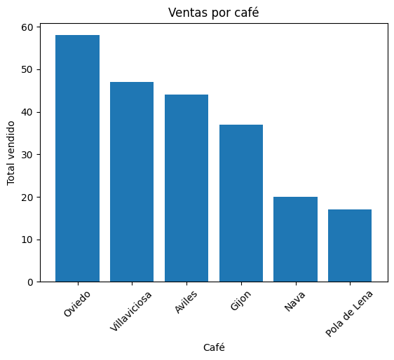

```python
plt.bar(zona2['nombre_zona'], zona2['unidades'])
plt.xticks(rotation=45)
plt.title("Ventas por café")
plt.xlabel("Café")
plt.ylabel("Total vendido")
plt.show()
```

### Consulta 3: Top 3 cafes por valoracion media (minimo 3 valoraciones)

```python
top3 = pd.read_sql("""SELECT c.nombre_cafe,
		ROUND(AVG(val.valoracion), 2) AS valoracion_media,
		COUNT(*) AS numero_valoraciones
FROM valoraciones AS val
JOIN cafe AS c ON val.id_cafe = c.id_cafe
GROUP BY c.nombre_cafe
HAVING COUNT(*) >= 3
ORDER BY valoracion_media DESC
LIMIT 3;""", conn)

estilizar(top3, zebra=True)
```

|  | nombre_cafe | valoracion_media | numero_valoraciones |
| --- | --- | --- | --- |
| 0 | Etiopia Yirgacheffe | 5.000000 | 35 |
| 1 | Colombia Huila | 5.000000 | 28 |
| 2 | Kenia Nyeri | 4.710000 | 14 |

### Consulta 4: Ticket medio por canal ('tienda' vs 'online')

```python
ticketmedio = pd.read_sql("""SELECT v.canal_venta,
	ROUND(SUM(dv.cantidad * dv.precio_unitario) / COUNT(DISTINCT v.id_venta), 2)
	AS ticket_medio
FROM venta AS v
JOIN detalle_venta AS dv ON v.id_venta = dv.id_venta
GROUP BY v.canal_venta;""", conn)

estilizar(ticketmedio, zebra=True)
```

|  | canal_venta | ticket_medio |
| --- | --- | --- |
| 0 | online | 33.690000 |
| 1 | tienda | 35.120000 |

### Consulta 5: recomendacion de cafe para "snobs"

```python
snobs = pd.read_sql("""SELECT c.nombre_cafe, dv.formato_paquete,
	ROUND(AVG(v.valoracion),2) AS "valoracion media"
FROM detalle_venta dv INNER JOIN cafe c
	ON dv.id_cafe = c.id_cafe
INNER JOIN valoraciones v
	ON c.id_cafe =  v.id_cafe
GROUP BY c.nombre_cafe
ORDER BY "valoracion media" DESC
LIMIT 3;""", conn)

estilizar(snobs, zebra=True)
```

|  | nombre_cafe | formato_paquete | valoracion media |
| --- | --- | --- | --- |
| 0 | Etiopia Yirgacheffe | 250g | 5.000000 |
| 1 | Colombia Huila | 250g | 5.000000 |
| 2 | Kenia Nyeri | 250g | 4.710000 |

[figure not shown]

### Consulta 6: Top 5 de clientes que mas compran

```python
top_clientes = pd.read_sql("""SELECT cl.id_cliente,
       cl.nombre_cliente,
       SUM(dv.cantidad * dv.precio_unitario) AS total_gastado
FROM cliente AS cl
JOIN venta AS v ON cl.id_cliente = v.id_cliente
JOIN detalle_venta AS dv ON v.id_venta = dv.id_venta
GROUP BY cl.id_cliente, cl.nombre_cliente
ORDER BY total_gastado DESC
LIMIT 5;""", conn)

estilizar(top_clientes, zebra=True)
```

|  | id_cliente | nombre_cliente | total_gastado |
| --- | --- | --- | --- |
| 0 | 101 | Aitana Suarez | 552.920000 |
| 1 | 103 | Carla Mier | 515.840000 |
| 2 | 108 | Hector Solares | 440.490000 |
| 3 | 110 | Jorge Cifuentes | 400.980000 |
| 4 | 105 | Elena Ruiz | 321.460000 |

### Consulta 7: ¿Qué canal tiene más operaciones de venta?

```python
canal = pd.read_sql("""SELECT
    cl.nombre_cliente,
    COUNT(DISTINCT CASE WHEN v.canal_venta = 'online' THEN v.id_venta END) AS compras_online,
    COUNT(DISTINCT CASE WHEN v.canal_venta = 'tienda' THEN v.id_venta END) AS compras_tienda,
    CASE
        WHEN COUNT(DISTINCT CASE WHEN v.canal_venta = 'online' THEN v.id_venta END) = 0
            THEN 'solo tienda'
        WHEN COUNT(DISTINCT CASE WHEN v.canal_venta = 'tienda' THEN v.id_venta END) = 0
            THEN 'solo online'
        ELSE 'ambos canales'
    END AS perfil_cliente
FROM cliente cl
JOIN venta v ON cl.id_cliente = v.id_cliente
GROUP BY cl.nombre_cliente
ORDER BY perfil_cliente;""", conn)

estilizar(canal, zebra=True)
```

|  | nombre_cliente | compras_online | compras_tienda | perfil_cliente |
| --- | --- | --- | --- | --- |
| 0 | Aitana Suarez | 7 | 7 | ambos canales |
| 1 | Bruno Mendez | 4 | 3 | ambos canales |
| 2 | Carla Mier | 6 | 8 | ambos canales |
| 3 | Diego Alvarez | 4 | 3 | ambos canales |
| 4 | Elena Ruiz | 3 | 4 | ambos canales |
| 5 | Fabian Torre | 4 | 3 | ambos canales |
| 6 | Gabriela Coto | 3 | 4 | ambos canales |
| 7 | Hector Solares | 8 | 6 | ambos canales |
| 8 | Iria Pravia | 3 | 4 | ambos canales |
| 9 | Jorge Cifuentes | 7 | 7 | ambos canales |

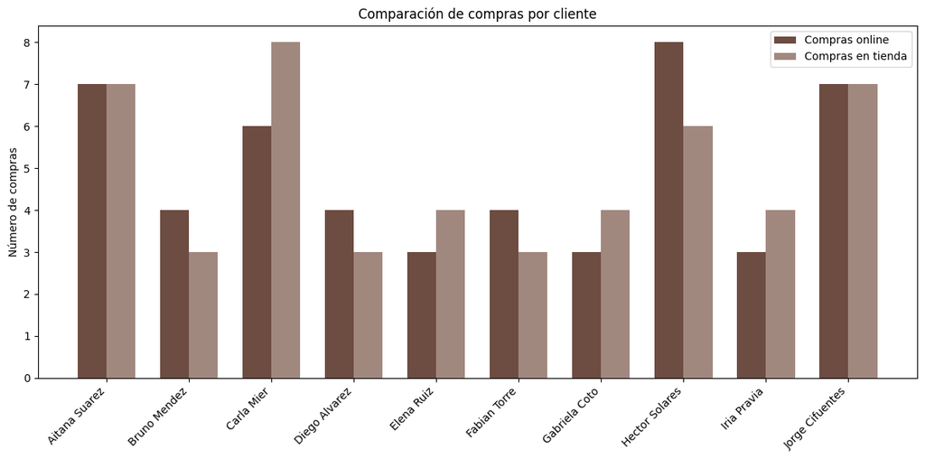

```python
import numpy as np

plt.figure(figsize=(12,6))

x = np.arange(len(canal['nombre_cliente']))   # posiciones en X
width = 0.35                               # ancho de cada barra

plt.bar(x - width/2, canal['compras_online'], width, label='Compras online', color='#6D4C41')
plt.bar(x + width/2, canal['compras_tienda'], width, label='Compras en tienda', color='#A1887F')

plt.xticks(x, canal['nombre_cliente'], rotation=45, ha='right')
plt.ylabel("Número de compras")
plt.title("Comparación de compras por cliente")
plt.legend()
plt.tight_layout()
plt.show()
```

### Consulta 8: Valoraciones vs proceso_cafe, nivel_tueste

```python
valoraciones = pd.read_sql("""SELECT
    c.proceso_cafe, c.nivel_tueste,
    ROUND(AVG(v.valoracion), 2) AS valoracion_media,
    COUNT(v.valoracion) AS total_opiniones
FROM CAFE AS c
INNER JOIN VALORACIONES AS v ON c.id_cafe = v.id_cafe
GROUP BY c.proceso_cafe, c.nivel_tueste
ORDER BY total_opiniones DESC;""", conn)

estilizar(valoraciones, zebra=True)
```

|  | proceso_cafe | nivel_tueste | valoracion_media | total_opiniones |
| --- | --- | --- | --- | --- |
| 0 | Lavado | Claro | 4.810000 | 63 |
| 1 | Lavado | Medio | 5.000000 | 28 |
| 2 | Honey | Medio-Oscuro | 4.430000 | 14 |
| 3 | Natural | Medio | 3.930000 | 14 |

### Consulta 9: ¿que formato se vende más?

```python
formato = pd.read_sql("""SELECT
    formato_paquete,
    COUNT(*) AS veces_comprado,
    SUM(cantidad) AS unidades_totales,
    ROUND(SUM("total_venta"), 2) AS facturacion_por_formato
FROM DETALLE_VENTA
GROUP BY formato_paquete
ORDER BY unidades_totales DESC;""", conn)

estilizar(formato, zebra=True)
```

|  | formato_paquete | veces_comprado | unidades_totales | facturacion_por_formato |
| --- | --- | --- | --- | --- |
| 0 | 250g | 44 | 84 | 1212.620000 |
| 1 | 500g | 40 | 72 | 1127.520000 |
| 2 | 1000 | 35 | 67 | 1031.340000 |

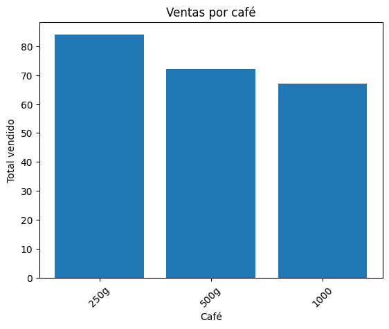

```python
plt.bar(formato['formato_paquete'], formato['unidades_totales'])
plt.xticks(rotation=45)
plt.title("Ventas por café")
plt.xlabel("Café")
plt.ylabel("Total vendido")
plt.show()
```